# Differential Expression - cell line drugging

Katleen De Preter

22/10/2023

# 1 Data preprocessing and exploration

## 1.2 Seting up the packages

To start, we need to install (and load) some CRAN and Bioconductor packages. You only need to do this once, that is why I commented the installation lines out. If packages are properly installed, you can just load the libraries. These are the packages you need for the differential expression analysis.

```r
#### Load libraries
#if (!requireNamespace("BiocManager", quietly = TRUE))
#  install.packages("BiocManager")

## DESeq2 for differential expression analysis
#BiocManager::install("DESeq2")
library(DESeq2)
```

```r
## Heatmaps for visualization purposes
#BiocManager::install("pheatmap")
library(pheatmap)

## BiocManager::install("ComplexHeatmap")
library(ComplexHeatmap)
```

[output not shown]

```r
## Packages that could be used for nice color themes
#install.packages("RColorBrewer")
library(RColorBrewer)

## VSN is used for transformation purposes
#BiocManager::install("vsn")
library(vsn)

## Easy to use package to make good looking Volcano plots
#BiocManager::install("EnhancedVolcano")
library(EnhancedVolcano)
## For gene set enrichment analysis
#BiocManager::install("msigdbr")
library(msigdbr)

#BiocManager::install("clusterProfiler")
library(clusterProfiler)
#BiocManager::install("fgsea")
library(fgsea)

## Tidyverse will be used to shape the data
#install.packages("tidyverse")
library(tidyverse)
#BiocManager::install("limma")
library(limma)
```

Some general tips and tricks: - use meaningful names (eg. counttable, annotationtable and not x, y), this will prevent mix ups when you are performing more complex analysis - check your dataframes/matrixes before you run the whole script (either use view or click on the dataframe/matrix in your ‘environment’). Are these looking like you expect? Do you have rownames/columnnames where you need them?

## 1.3 Reading in the Counts data

Our count data is saved as a tab separated file. We need to use a read function that uses tabs as a separator. We need to generate a data frame that has the samples as column names and genes as rownames. Inspect the RNAseq_data with the function view.

```r
### Import data and make CountTable
readr::local_edition(1) # this is a line that I need to run to avoid an error on vroom on my mac
RNAseq_data <- read_tsv("GSE95189_RNAseq_BEZ.txt") %>% column_to_rownames("gene_id")
```

## 1.4 Reading in the sample information

We read in the sample information file as tibble and then transform to a dataframe with the “Treatment” (BEZ or DMSO) information in the first column.

```r
AnnotationTable <- read_tsv("GSE95189_sampleinfo.txt") %>% column_to_rownames("SampleID")
```

## 1.5 Making a DDS object for DESeq analysis

DESeq needs a dds object to perform its calculations on. We will create this by using our count table, annotation table and we will feed a ‘design’. This design tells to DESeq what sample groups you want to compare (in our case we compare BEZ vs DMSO). This command give a warning message telling you that characters are converted to factors, you can ignore this message.

```r
### Make a dds object, including the design of the DE experiment
dds <- DESeqDataSetFromMatrix(countData = RNAseq_data,
                              colData = AnnotationTable,
                              design = ~Treatment)
```

```
## Warning in DESeqDataSet(se, design = design, ignoreRank): some variables in
## design formula are characters, converting to factors
```

## 1.6 Filter data

Filter data to give your test more power. In this case, we will only keep the genes with more than 10 counts when we sum the counts over all samples. If you want to be more strict, you can for instance choose to filter on 20 or 50 counts. Change this parameter, and identify the effect on the outcome.

```r
### Prefilter the data
keep <- rowSums(counts(dds)) >= 10
dds <- dds[keep,]
```

## 1.7 Data normalization and log-transformation

Using the function estimateSizeFactors you can normalize the raw RNA-seq counts using the median ratio method (DeSeq normalisation method). After that, we log transform the normalized count data.

```r
normdata <- estimateSizeFactors(dds)

### with the function sizeFactors you can calculate the normalization factor used to normalize the raw counts and get normalized counts.

sizeFactors(normdata)
```

```
##    DMSO_1    DMSO_2    DMSO_3     BEZ_1     BEZ_2     BEZ_3
## 0.9333743 1.0386279 1.1029943 0.9232473 0.9199755 1.1517147
```

```r
### Here we transform the normalized counts with 2log. As (normalized) counts can be zero, we first add 1, so that for all normalized counts a log-transformation can be performed (as log2(0)=-Inf). An alternative is to use rlog (regularized log).

normalized_counts <- log2(counts(normdata, normalized=TRUE)+1)
```

## 1.8 Data exploration with PCA

In the next step we perform principal component analysis to visualize the similarity and difference of the different samples.

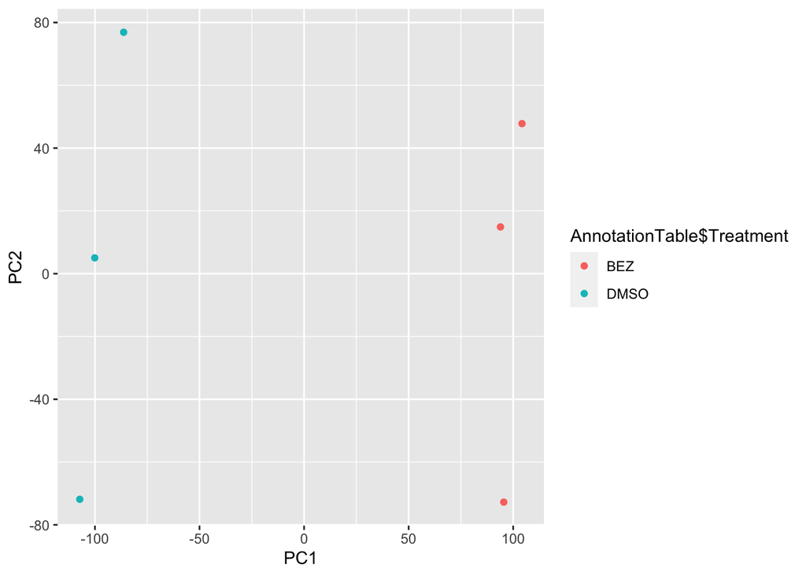

```r
### prcomp is the function used to calculate the prinicple components (scale = TRUE is to perform PCA on standardized data). By performing prcomp on the transposed data, principle component analysis is performed at the sample level (instead of at the genelevel). pca$x is a matrix and data need to be converted to a tibble or dataframe for ggplot analysis. The samples are coloured according to their treatment (BEZ or DMSO).

pca=prcomp(t(normalized_counts),scale=TRUE)
pca$x %>% as.data.frame() %>%
        ggplot(aes(x=PC1,y=PC2,color=AnnotationTable$Treatment)) +
        geom_point()
```

## 1.9 Data exploration with heatmap

Similar as for PCA we perform hierarchical clustering and heatmap visualization to explore the similarities between the samples.

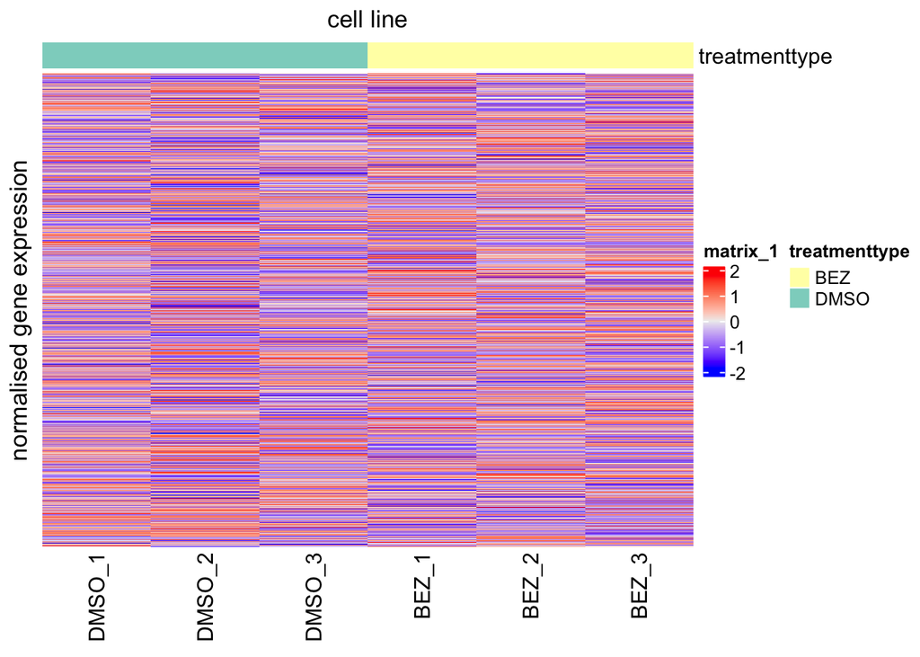

```r
### We first select only the data from the top 1000 genes (heatmap visualization on all genes will be too computer intensive)
select_normalized_counts <- as.data.frame(normalized_counts) %>%
        sample_n(1000)

colors_treatmenttype <- c("#8DD3C7", "#FFFFB3")
names(colors_treatmenttype) <- c("DMSO","BEZ")
column_ha = HeatmapAnnotation(treatmenttype = as.factor(AnnotationTable$Treatment), col = list(treatmenttype=colors_treatmenttype))

## First option: just a heatmap without hierarchical clustering (check all arguments in this function)
dataforheatmap=t(scale(t(as.matrix(select_normalized_counts)))) #we scale the data at row-level therefore we need to transform the data
Heatmap(dataforheatmap,
        show_row_names = FALSE, show_column_names = TRUE,
        cluster_rows = FALSE, cluster_columns = FALSE,
        row_title = "normalised gene expression", column_title = "cell line",
        show_row_dend = FALSE,
        show_column_dend = FALSE,
        top_annotation = column_ha)
```

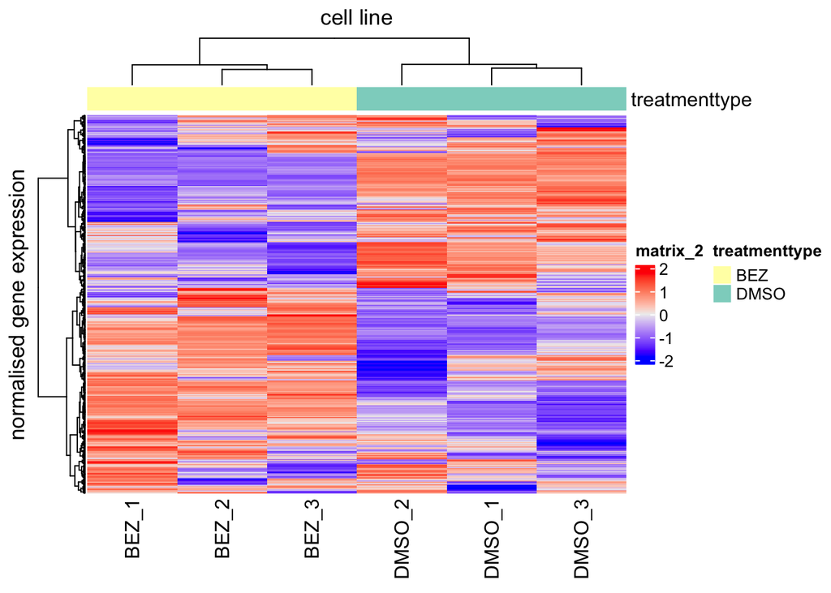

```r
## Second option: a heatmap including hierarchical clustering visualised with a dendrogram (distance = Manhattan and clustering method = ward.D2)
Heatmap(dataforheatmap,
        show_row_names = FALSE, show_column_names = TRUE,
        cluster_rows = TRUE, cluster_columns = TRUE,
        clustering_distance_rows = "manhattan", clustering_method_rows = "ward.D2",
        clustering_distance_columns = "manhattan", clustering_method_columns = "ward.D2",
        row_title = "normalised gene expression", column_title = "cell line",
        show_row_dend = TRUE,
        show_column_dend = TRUE,
        top_annotation = column_ha)
```

# 2 DE analysis

## 2.1 DEseq analysis

If you use the DESeq comment on the counts you will perform normalization and differential expression analysis in one go (so we start again from the dds object and perform DESeq on it (and therefore we do not work further with the normalized_counts object). The different steps done by DESeq will pop up in your console. Size factors and dispersion are estimated for normalization purposes. Afterwards the model/design is fit and all genes are tested for differential expression. In this case, the design is very simple (comparing DMSO vs BEZ treatment), but you can make much more complex designs (not part of this course).

```r
### Differential expression analysis
dds <- DESeq(dds)
```

## 2.2 Inspecting DESeq results

With the results function we can extract a table with Fold changes, P-values, … from the dds object. Standard, a cut-off of 0.1 is used, but we can be stricter if we want by changing some of the parameters (e.g., padj < 0.05 and log2(fold-change) of more than 1).

```r
### Retrieve results (with standard settings, i.e. alpha=0.1)
res <- results(dds)
summary(res)
```

```
##
## out of 21696 with nonzero total read count
## adjusted p-value < 0.1
## LFC > 0 (up)       : 4790, 22%
## LFC < 0 (down)     : 4436, 20%
## outliers [1]       : 8, 0.037%
## low counts [2]     : 2104, 9.7%
## (mean count < 3)
## [1] see 'cooksCutoff' argument of ?results
## [2] see 'independentFiltering' argument of ?results
```

```r
?results()

## here we select the genes with a padj value lower than 0.05 and a log2foldchange of more than 1
res <- results(dds, alpha=0.05, lfcThreshold = 1)
summary(res)
```

```
##
## out of 21696 with nonzero total read count
## adjusted p-value < 0.05
## LFC > 1.00 (up)    : 372, 1.7%
## LFC < -1.00 (down) : 174, 0.8%
## outliers [1]       : 8, 0.037%
## low counts [2]     : 3786, 17%
## (mean count < 6)
## [1] see 'cooksCutoff' argument of ?results
## [2] see 'independentFiltering' argument of ?results
```

```r
## here we sort the resultstable based on the adjusted p-value (from small to large), you can compare the objects res and resOrdered
resOrdered <- res[order(res$padj),]
resOrdered
```

```
## log2 fold change (MLE): Treatment DMSO vs BEZ
## Wald test p-value: Treatment DMSO vs BEZ
## DataFrame with 21696 rows and 6 columns
##                  baseMean log2FoldChange     lfcSE      stat       pvalue
##                 <numeric>      <numeric> <numeric> <numeric>    <numeric>
## ENSG00000171848   1502.20        3.91689 0.1068548   27.2976 4.52394e-164
## ENSG00000101057   1375.38        4.35236 0.1252557   26.7641 8.45595e-158
## ENSG00000177410   1948.11       -3.20476 0.0900519  -24.4833 2.22720e-132
## ENSG00000116133   1300.51        3.50931 0.1048253   23.9380 1.23078e-126
## ENSG00000143476   1145.58        3.37780 0.1048609   22.6758 7.77132e-114
## ...                   ...            ...       ...       ...          ...
## ENSG00000283599   3.09242       1.887356   1.26574  0.701056     0.483268
## ENSG00000283667   2.98074       1.360575   1.24612  0.289358     0.772307
## ENSG00000283689   2.15341       2.460583   1.63582  0.892877     0.371923
## ENSG00000283697   1.69816      -0.158709   1.84843  0.000000     1.000000
## ENSG00000283698   2.00060      -1.645188   1.67026 -0.386281     0.699289
##                         padj
##                    <numeric>
## ENSG00000171848 8.09876e-160
## ENSG00000101057 7.56893e-154
## ENSG00000177410 1.32905e-128
## ENSG00000116133 5.50837e-123
## ENSG00000143476 2.78244e-110
## ...                      ...
## ENSG00000283599           NA
## ENSG00000283667           NA
## ENSG00000283689           NA
## ENSG00000283697           NA
## ENSG00000283698           NA
```